# Project Foundations for Data Science: FoodHub Data Analysis

**Marks: 60**

### Context

The number of restaurants in New York is increasing day by day. Lots of students and busy professionals rely on those restaurants due to their hectic lifestyles. Online food delivery service is a great option for them. It provides them with good food from their favorite restaurants. A food aggregator company FoodHub offers access to multiple restaurants through a single smartphone app.

The app allows the restaurants to receive a direct online order from a customer. The app assigns a delivery person from the company to pick up the order after it is confirmed by the restaurant. The delivery person then uses the map to reach the restaurant and waits for the food package. Once the food package is handed over to the delivery person, he/she confirms the pick-up in the app and travels to the customer's location to deliver the food. The delivery person confirms the drop-off in the app after delivering the food package to the customer. The customer can rate the order in the app. The food aggregator earns money by collecting a fixed margin of the delivery order from the restaurants.

### Objective

The food aggregator company has stored the data of the different orders made by the registered customers in their online portal. They want to analyze the data to get a fair idea about the demand of different restaurants which will help them in enhancing their customer experience. Suppose you are hired as a Data Scientist in this company and the Data Science team has shared some of the key questions that need to be answered. Perform the data analysis to find answers to these questions that will help the company to improve the business.

### Data Description

The data contains the different data related to a food order. The detailed data dictionary is given below.

### Data Dictionary

- order_id: Unique ID of the order
- customer_id: ID of the customer who ordered the food
- restaurant_name: Name of the restaurant
- cuisine_type: Cuisine ordered by the customer
- cost: Cost of the order
- day_of_the_week: Indicates whether the order is placed on a weekday or weekend (The weekday is from Monday to Friday and the weekend is Saturday and Sunday)
- rating: Rating given by the customer out of 5
- food_preparation_time: Time (in minutes) taken by the restaurant to prepare the food. This is calculated by taking the difference between the timestamps of the restaurant's order confirmation and the delivery person's pick-up confirmation.
- delivery_time: Time (in minutes) taken by the delivery person to deliver the food package. This is calculated by taking the difference between the timestamps of the delivery person's pick-up confirmation and drop-off information

### Let us start by importing the required libraries

```python
# import libraries for data manipulation
import numpy as np
import pandas as pd

# import libraries for data visualization
import matplotlib.pyplot as plt
import seaborn as sns
import warnings
warnings.filterwarnings('ignore')
```

### Understanding the structure of the data

```python
# read the data
df = pd.read_csv('foodhub_order.csv')
# returns the first 5 rows
df.head()
```

|  | order_id | customer_id | restaurant_name | cuisine_type | cost_of_the_order | day_of_the_week | rating | food_preparation_time | delivery_time |
| --- | --- | --- | --- | --- | --- | --- | --- | --- | --- |
| 0 | 1477147 | 337525 | Hangawi | Korean | 30.75 | Weekend | Not given | 25 | 20 |
| 1 | 1477685 | 358141 | Blue Ribbon Sushi Izakaya | Japanese | 12.08 | Weekend | Not given | 25 | 23 |
| 2 | 1477070 | 66393 | Cafe Habana | Mexican | 12.23 | Weekday | 5 | 23 | 28 |
| 3 | 1477334 | 106968 | Blue Ribbon Fried Chicken | American | 29.20 | Weekend | 3 | 25 | 15 |
| 4 | 1478249 | 76942 | Dirty Bird to Go | American | 11.59 | Weekday | 4 | 25 | 24 |

#### Observations:

The DataFrame has 9 columns as mentioned in the Data Dictionary. Data in each row corresponds to the order placed by a customer.

### **Question 1:** How many rows and columns are present in the data? [0.5 mark]

```python
# Shape shows the number of rows and columns in the dataset
df.shape
```

```
(1898, 9)
```

#### Observations:

The dataset has 1898 rows and 9 columns.

### **Question 2:** What are the datatypes of the different columns in the dataset? (The info() function can be used) [0.5 mark]

```python
# Info function provides us a summary of the dataset (datatypes of each column, number of non-null values in each column, size of the dataset etc.)
df.info()
```

```
<class 'pandas.core.frame.DataFrame'>
RangeIndex: 1898 entries, 0 to 1897
Data columns (total 9 columns):
 #   Column                 Non-Null Count  Dtype
---  ------                 --------------  -----
 0   order_id               1898 non-null   int64
 1   customer_id            1898 non-null   int64
 2   restaurant_name        1898 non-null   object
 3   cuisine_type           1898 non-null   object
 4   cost_of_the_order      1898 non-null   float64
 5   day_of_the_week        1898 non-null   object
 6   rating                 1898 non-null   object
 7   food_preparation_time  1898 non-null   int64
 8   delivery_time          1898 non-null   int64
dtypes: float64(1), int64(4), object(4)
memory usage: 133.6+ KB
```

#### Observations:

order_id - int64

customer_id - int64

restaurant_name - object

cuisine_type - object

cost_of_the_order - float64

day_of_the_week - object

rating - object

food_preparation_time - int64

delivery_time - int64

#### On the rating column the data can be int as a mark given by the costumer or "Not given" if they didn't provide any feedback about the food.

#### Type of information saved on each column is already explained on the descrpition (for example: preparation time calculation and measure unit)

### **Question 3:** Are there any missing values in the data? If yes, treat them using an appropriate method. [1 mark]

```python
# Check for missing values in the dataset
missing_values = df.isnull().sum()
missing_values
```

```
order_id                 0
customer_id              0
restaurant_name          0
cuisine_type             0
cost_of_the_order        0
day_of_the_week          0
rating                   0
food_preparation_time    0
delivery_time            0
dtype: int64
```

#### Observations:

There are no missing values on de dataset besides the 'Not given' on the rating, that are already filled.

### **Question 4:** Check the statistical summary of the data. What is the minimum, average, and maximum time it takes for food to be prepared once an order is placed? [2 marks]

```python
df.describe()
#Describe is the method used to get some basic statistics (mean, min, max, std, etx.).
```

|  | order_id | customer_id | cost_of_the_order | food_preparation_time | delivery_time |
| --- | --- | --- | --- | --- | --- |
| count | 1.898000e+03 | 1898.000000 | 1898.000000 | 1898.000000 | 1898.000000 |
| mean | 1.477496e+06 | 171168.478398 | 16.498851 | 27.371970 | 24.161749 |
| std | 5.480497e+02 | 113698.139743 | 7.483812 | 4.632481 | 4.972637 |
| min | 1.476547e+06 | 1311.000000 | 4.470000 | 20.000000 | 15.000000 |
| 25% | 1.477021e+06 | 77787.750000 | 12.080000 | 23.000000 | 20.000000 |
| 50% | 1.477496e+06 | 128600.000000 | 14.140000 | 27.000000 | 25.000000 |
| 75% | 1.477970e+06 | 270525.000000 | 22.297500 | 31.000000 | 28.000000 |
| max | 1.478444e+06 | 405334.000000 | 35.410000 | 35.000000 | 33.000000 |

#### Observations:

Preparation Time:

- Minimum: 20 min
- Maximum: 35 min
- Average: 27.37 min

The cost order has relativly high std and it's normal, because they're not ordering food to the same restaurants or type of food, so costs would be different between those.

### **Question 5:** How many orders are not rated? [1 mark]

```python
# Not rated orders have 'Not given' as value on the rating column.
no_rated = df[df['rating'] == 'Not given'].shape[0]
no_rated
```

```
736
```

#### Observations: 736 orders were not rated out of 1898

### Exploratory Data Analysis (EDA)

### **Question 6:** Explore all the variables and provide observations on their distributions. (Generally, histograms, boxplots, countplots, etc. are used for univariate exploration.) [9 marks]

#### **Orders**

```python
orders_count = df['order_id'].nunique() # number of unique order ids
orders_count
```

```
1898
```

**Observations:** Dataset has no repeated orders with a total of 1898.

#### **Costumers**

```python
costumers_count = df['customer_id'].nunique() # or df['customer_id'].value_counts().shape[0] it counts the unique values
costumers_count
```

```
1200
```

**Observations:** The app has 1200 unique costumers

#### **Restaurants**

```python
restaurants_count = df['restaurant_name'].nunique() # Number of restaurants in the dataset
restaurants_count
```

```
178
```

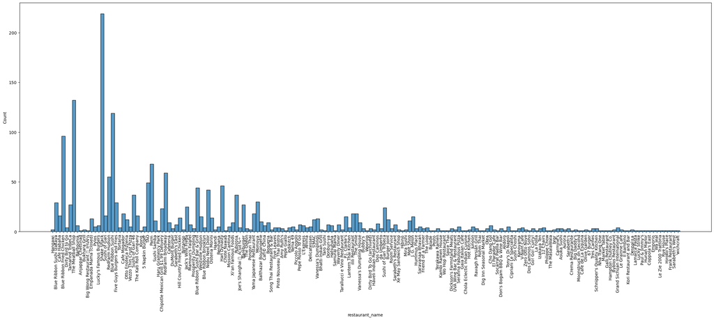

```python
plt.figure(figsize=(30, 10))
sns.histplot(df['restaurant_name'])
plt.xticks(rotation=90)
plt.show()
```

```python
restaurants_orders_count = df['restaurant_name'].value_counts()
restaurants_orders_count

top_4_restaurants_percentage = (restaurants_orders_count[:4].sum() / orders_count) * 100 # Top 4 restaurants percentage
print(f'Top 4 restaurants percentage: {top_4_restaurants_percentage:.2f}%')
```

```
Top 4 restaurants percentage: 29.82%
```

**Observations:** We have a total of 178 restaurants with a variety of number of orders, but just a few acumulating most of the orders like Shake Shack.

Top 4 restaurants acumulate 29.82% of the orders.

#### **Cuisine Type**

```python
cuisines_count = df['cuisine_type'].nunique() # Number of unique cuisine types
cuisines_count
```

```
14
```

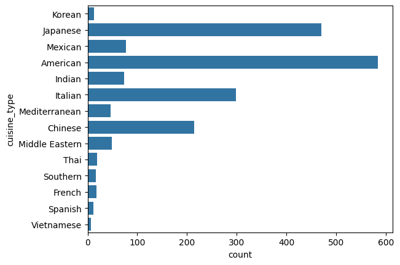

```python
sns.countplot(df['cuisine_type'])
plt.show()
```

```python
cuisine_type = df['cuisine_type'].value_counts()
cuisine_type.head(4)

top_4_cuisines_percentage = (cuisine_type.head(4).sum() / df.shape[0]) * 100 # Calculate the percentage of orders for the top 4 cuisine types
print(f"Percentage of orders for the top 4 cuisine types: {top_4_cuisines_percentage:.2f}%")
```

```
Percentage of orders for the top 4 cuisine types: 82.56%
```

**Observations:** 14 cuisine types with 4 of them having the most of the orders, acumulating 82.56% of the orders.

#### **Cost of the Order**

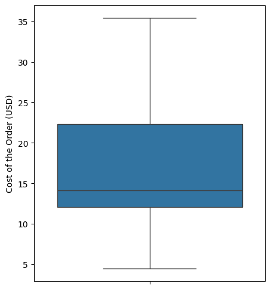

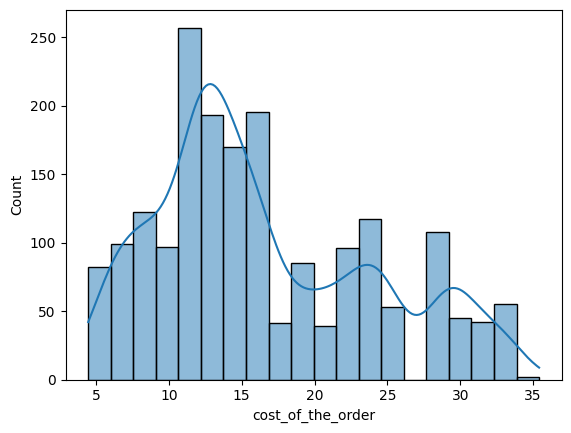

```python
plt.figure(figsize=(5, 6))
sns.boxplot(y='cost_of_the_order', data=df)
plt.ylabel('Cost of the Order (USD)')
plt.show()

sns.histplot(df['cost_of_the_order'], bins=20, kde = True)
plt.show()
```

**Observations:** On both graphs we see that the price of the orders has a right-skewed distribution, this meaning that most of the prices are in the 10-15 USD frame, clearly cost can't go under 0 USD and cost doesn't go too hight except in a few cases.

#### **Day of the Week**

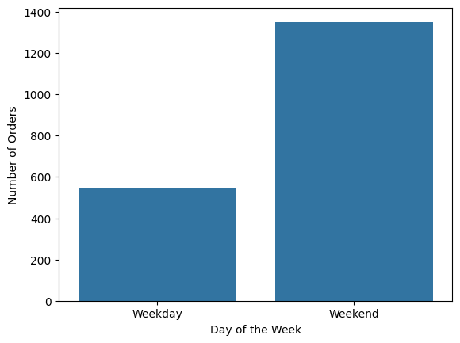

```python
sns.countplot(x='day_of_the_week', order = ["Weekday", "Weekend"], data=df)
plt.xlabel('Day of the Week')
plt.ylabel('Number of Orders')
plt.show()
```

**Observations:** We can clearly see that people prefers order food on weekends with more than twice the orders on weekends than week days.

- It could be because are their free days and the don't want to spend time cooking and everything that comes with it.

#### **Ratings**

```python
ratings_given_count = df['rating'].value_counts() # Number of ratings given
ratings_given_count
```

```
rating
Not given    736
5            588
4            386
3            188
Name: count, dtype: int64
```

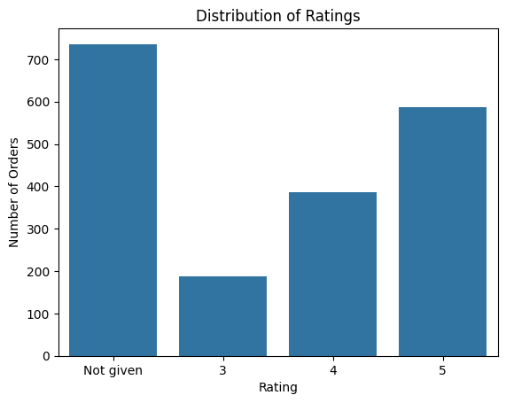

```python
sns.countplot(x='rating', data=df, order=['Not given', '3', '4', '5'])
plt.xlabel('Rating')
plt.ylabel('Number of Orders')
plt.title('Distribution of Ratings')
plt.show()
```

#### **Food Preparation Time, Delivery Time and Total Order Time**

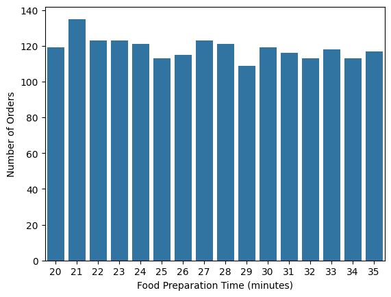

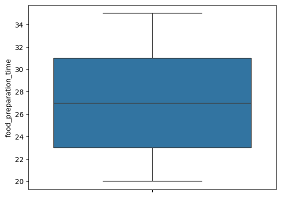

```python
sns.countplot(x='food_preparation_time', data=df)
plt.xlabel('Food Preparation Time (minutes)')
plt.ylabel('Number of Orders')
plt.show()

sns.boxplot(y = 'food_preparation_time', data = df)
plt.show()
```

**Observations**: The preparations time has an uniform distribution. This means all preparation times are equally probable.

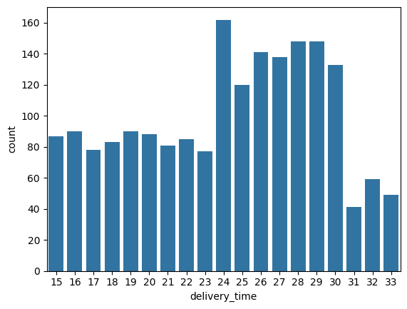

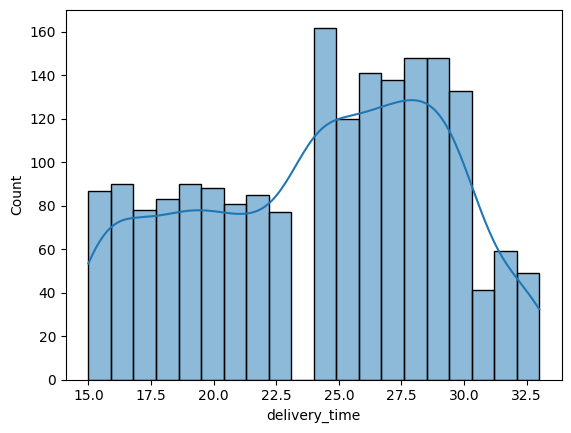

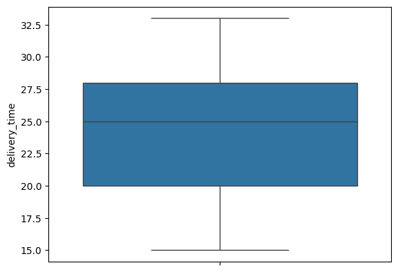

```python
sns.countplot(x='delivery_time', data=df)
plt.show()

sns.histplot(df['delivery_time'], bins=20, kde = True)
plt.show()

sns.boxplot(y = 'delivery_time', data = df)
plt.show()
```

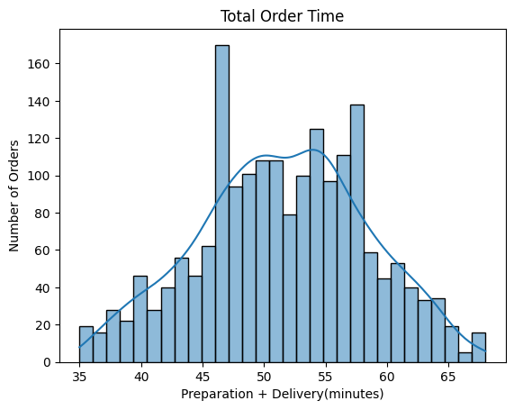

```python
total_order_time = df['food_preparation_time'] + df['delivery_time'] # Total time of the order calculation

sns.histplot(total_order_time, bins=30, kde = True)
plt.ylabel('Number of Orders')
plt.xlabel('Preparation + Delivery(minutes)')
plt.title('Total Order Time')
```

**Observations:** The total order time is normally distributed it meaning that the total order time is pretty consistent. With this we can use the mean as a reliable estimate for any purpose (marketing, costumers orders planifications, etc.)

### **Question 7**: Which are the top 5 restaurants in terms of the number of orders received? [1 mark]

```python
# Count the number of orders made to each restaurant
restaurant_order_counts = df['restaurant_name'].value_counts()
restaurant_order_counts.head()

# value_counts does already sort the values in descending order.
# There are some built in functions in pandas that can be used to sort or just implement some sorting algorithms.
```

```
restaurant_name
Shake Shack                  219
The Meatball Shop            132
Blue Ribbon Sushi            119
Blue Ribbon Fried Chicken     96
Parm                          68
Name: count, dtype: int64
```

#### Observations:

Shake Shack with 219 orders

The Meatball Shop with 132 orders

Blue Ribbon Sushi with 119 orders

Blue Ribbon Fried Chicken with 96 orders

Parm with 68 orders

### **Question 8**: Which is the most popular cuisine on weekends? [1 mark]

```python
weekends_orders = df[df['day_of_the_week'] == 'Weekend'] # filter the data for weekends

weekends_cuisine_type = weekends_orders['cuisine_type'].value_counts() # count the number of orders made to each cuisine type

weekends_cuisine_type.head(1) # get the most ordered cuisine type
```

```
cuisine_type
American    415
Name: count, dtype: int64
```

#### Observations:

The most popular cuisine on weekends is American cuisine.

### **Question 9**: What percentage of the orders cost more than 20 dollars? [2 marks]

```python
twt_dollars_orders = df[df['cost_of_the_order'] > 20].shape[0] # Filtering >20 USD orders and counting them
print(str(round(twt_dollars_orders*100/df.shape[0],2))+"%") # Using the numerator and denominator to calculate the percentage
```

```
29.24%
```

#### Observations:

29.24% of the orders cost more than 20 dollars.

### **Question 10**: What is the mean order delivery time? [1 mark]

```python
delivery_time = df['delivery_time'] # get the delivery time column
round(float(delivery_time.mean()), 2)
```

```
24.16
```

#### Observations: Average delivery time = 24.16 min

### **Question 11:** The company has decided to give 20% discount vouchers to the top 3 most frequent customers. Find the IDs of these customers and the number of orders they placed. [1 mark]

```python
costumer_frecuency = df['customer_id'].value_counts() # value_counts() returns the frequency of each unique value in the column
costumer_frecuency.head(3)
```

```
customer_id
52832    13
47440    10
83287     9
Name: count, dtype: int64
```

#### Observations:

the top 3 frequent costumers are:

1.- 52832 with 13 orders

2.- 47440 with 10 orders

3.- 83287 with 9 orders

### **Question 12**: Perform a multivariate analysis to explore relationships between the important variables in the dataset. (It is a good idea to explore relations between numerical variables as well as relations between numerical and categorical variables) [10 marks]

#### **Cuisine vs Preparation Time**

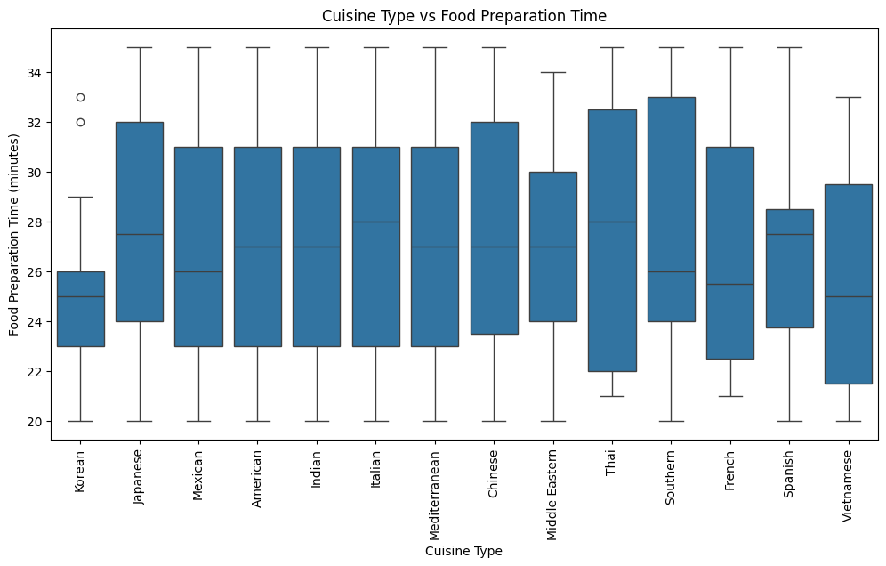

```python
plt.figure(figsize=(12, 6))
sns.boxplot(x='cuisine_type', y='food_preparation_time', data=df)
plt.xticks(rotation=90)
plt.xlabel('Cuisine Type')
plt.ylabel('Food Preparation Time (minutes)')
plt.title('Cuisine Type vs Food Preparation Time')
plt.show()
```

#### **Cuisine vs Cost**

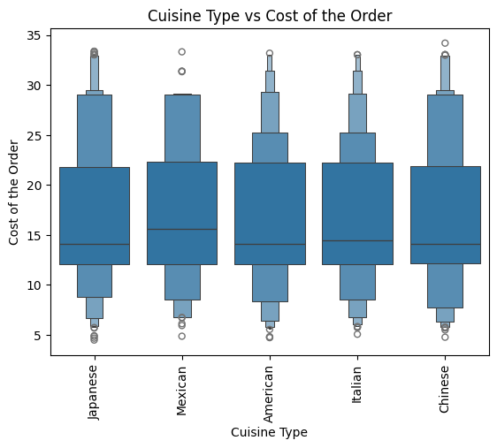

```python
top_cuisines = df['cuisine_type'].value_counts().head(5).index
filtered_df = df[df['cuisine_type'].isin(top_cuisines)]
sns.boxenplot(x = 'cuisine_type', y = 'cost_of_the_order', data = filtered_df)
plt.xticks(rotation=90)
plt.xlabel('Cuisine Type')
plt.ylabel('Cost of the Order')
plt.title('Cuisine Type vs Cost of the Order')
plt.show()
```

**Observations:** We're just checking the most ordered cuisine types, because those are which have enough data to get some inferences out of it. Cost of the orders seem similar, with no big difference between different cuisine types.

#### **Restaurant vs Cost**

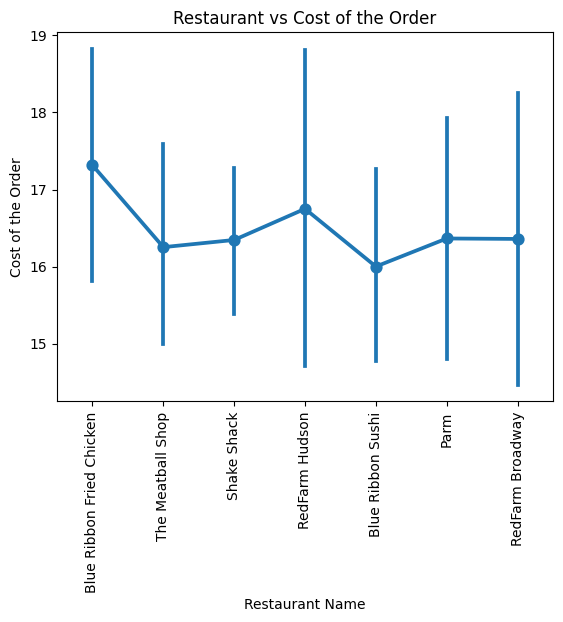

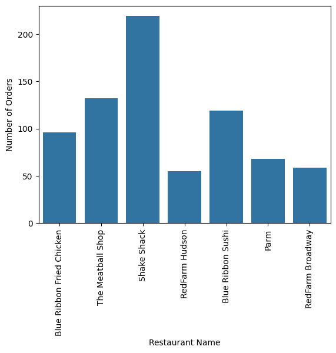

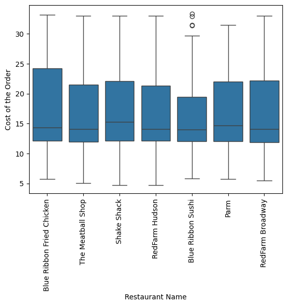

```python
restaurants_orders_count = df['restaurant_name'].value_counts() # count the number of orders made to each restaurant
restaurants_50_orders = restaurants_orders_count[restaurants_orders_count > 50] # filter the restaurants with more than 50 orders

sns.pointplot(x = 'restaurant_name', y = 'cost_of_the_order', data = df[df['restaurant_name'].isin(restaurants_50_orders.index)])
plt.xticks(rotation=90)
plt.xlabel('Restaurant Name')
plt.ylabel('Cost of the Order')
plt.title('Restaurant vs Cost of the Order')
plt.show()

sns.countplot(x = 'restaurant_name', data = df[df['restaurant_name'].isin(restaurants_50_orders.index)])
plt.xticks(rotation=90)
plt.xlabel('Restaurant Name')
plt.ylabel('Number of Orders')
plt.show()

sns.boxplot(x = 'restaurant_name', y = 'cost_of_the_order', data = df[df['restaurant_name'].isin(restaurants_50_orders.index)])
xticks = plt.xticks(rotation=90)
plt.xlabel('Restaurant Name')
plt.ylabel('Cost of the Order')
plt.show()
```

**Observations:** Means are pretty equal, we can see some outliers, but nothing too out of the range of costs that we manage.

#### **Rating vs Total Order Time**

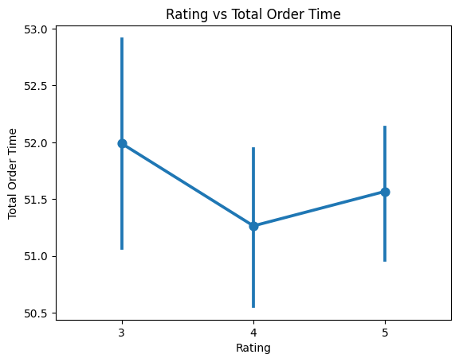

```python
df_copy = df.copy()
df_copy['total_order_time'] = df_copy['food_preparation_time'] + df_copy['delivery_time'] # calculate the total order time

sns.pointplot(x = 'rating', y = 'total_order_time', order = ['3','4','5'], data = df_copy)
plt.xlabel('Rating')
plt.ylabel('Total Order Time')
plt.title('Rating vs Total Order Time')
plt.show()
```

#### **Rating vs Cost**

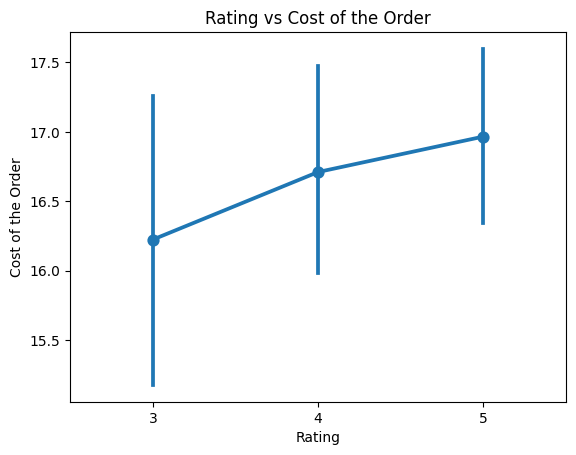

```python
sns.pointplot(x = 'rating', y = 'cost_of_the_order', order = ['3','4','5'], data = df)
plt.xlabel('Rating')
plt.ylabel('Cost of the Order')
plt.title('Rating vs Cost of the Order')

plt.show()
```

**Observations:** Ratings tend to be higher when the cost of the order is higher. Higher prices are usually associated with better product quality.

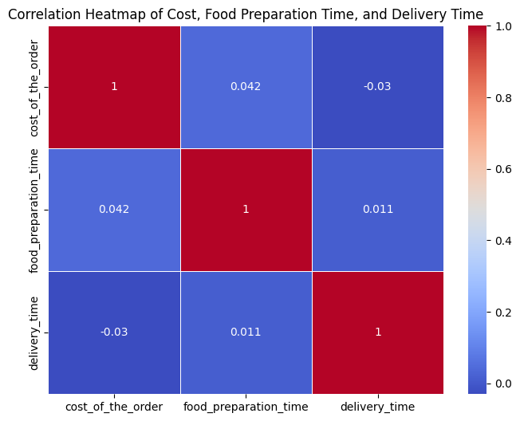

```python
heatmap_data = df[['cost_of_the_order', 'food_preparation_time', 'delivery_time']]

correlation_matrix = heatmap_data.corr()

plt.figure(figsize=(8, 6))
sns.heatmap(correlation_matrix, annot=True, cmap='coolwarm', linewidths=0.5)
plt.title('Correlation Heatmap of Cost, Food Preparation Time, and Delivery Time')
plt.show()
```

### **Question 13:** The company wants to provide a promotional offer in the advertisement of the restaurants. The condition to get the offer is that the restaurants must have a rating count of more than 50 and the average rating should be greater than 4. Find the restaurants fulfilling the criteria to get the promotional offer. [3 marks]

```python
# First: filter restaurants with more than 50 ratings

ratings_given = df[df['rating'] != 'Not given'].copy()
ratings_given['rating'] = ratings_given['rating'].astype(int)
restaurant_rating_counts = ratings_given['restaurant_name'].value_counts()
restaurants_50_ratings = restaurant_rating_counts[restaurant_rating_counts > 50]

# Second: filter by rating > 4

average_rating = ratings_given.groupby('restaurant_name')['rating'].mean()
eligible_restaurants = average_rating[average_rating > 4].index.intersection(restaurants_50_ratings.index)
eligible_restaurants
```

```
Index(['Blue Ribbon Fried Chicken', 'Blue Ribbon Sushi', 'Shake Shack',
       'The Meatball Shop'],
      dtype='object', name='restaurant_name')
```

#### Observations:

The restaurants fulfilling the >50 ratings and >4 average ratings are:

- Blue Ribbon Fried Chicken
- Blue Ribbon Sushi
- Shake Shack
- The Meatball Shop

### **Question 14:** The company charges the restaurant 25% on the orders having cost greater than 20 dollars and 15% on the orders having cost greater than 5 dollars. Find the net revenue generated by the company across all orders. [3 marks]

```python
revenue = 0

for index, order in df.iterrows(): # iterate over the indexes and rows of the dataframe
    if order['cost_of_the_order'] > 20: # check if the cost of the order is greater than 20
        revenue += order['cost_of_the_order'] * 0.25
    elif order['cost_of_the_order'] > 5: # check if the cost of the order is greater than 5 and not greater than 20, because those were filtered in the previous condition.
        revenue += order['cost_of_the_order'] * 0.15

revenue
```

```
6166.302999999994
```

#### Observations:

The revenue across all orders is 6166.30 USD

### **Question 15:** The company wants to analyze the total time required to deliver the food. What percentage of orders take more than 60 minutes to get delivered from the time the order is placed? (The food has to be prepared and then delivered.) [2 marks]

```python
total_order_time = df['food_preparation_time'] + df['delivery_time'] # calculate the total order time
high_total_order_time = total_order_time[total_order_time > 60] # filter the orders with total order time greater than 60 minutes
high_total_order_time_percentage = high_total_order_time.shape[0] * 100 / total_order_time.shape[0] # calculate the percentage of orders with total order time greater than 60 minutes
print(str(round(high_total_order_time_percentage,2)) + '%')
```

```
10.54%
```

#### Observations:

10.54% of the orders takes more than 60 min to be delivered since it was ordered.

### **Question 16:** The company wants to analyze the delivery time of the orders on weekdays and weekends. How does the mean delivery time vary during weekdays and weekends? [2 marks]

```
Weekend delivery time average: 22.47
Weekend delivery time standar deviation: 4.63
Week delivery time average: 28.34
Week delivery time standar deviation: 2.89
Average difference between weekend and weekday delivery time: -5.87
```

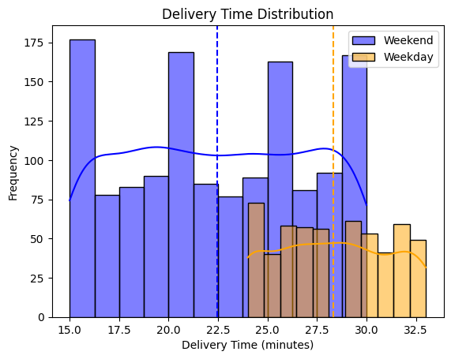

```python
weekend_orders = df[df['day_of_the_week'] == 'Weekend'].copy() # filter the data for weekends
print("Weekend delivery time average: " + str(round(weekend_orders['delivery_time'].mean(),2))) # calculate the average delivery time for weekends
print("Weekend delivery time standar deviation: " + str(round(weekend_orders['delivery_time'].std(),2))) # calculate the standard deviation of delivery time for weekends

week_orders = df[df['day_of_the_week'] == 'Weekday'].copy() # filter the data for weekdays
print("Week delivery time average: " + str(round(week_orders['delivery_time'].mean(),2))) # calculate the average delivery time for weekdays
print("Week delivery time standar deviation: " + str(round(week_orders['delivery_time'].std(),2))) # calculate the standard deviation of delivery time for weekdays

print("Average difference between weekend and weekday delivery time: " + str(round(weekend_orders['delivery_time'].mean() - week_orders['delivery_time'].mean(),2))) # calculate the average difference between weekend and weekday delivery time

sns.histplot(weekend_orders['delivery_time'], kde=True, color='blue', label='Weekend')
sns.histplot(week_orders['delivery_time'], kde=True, color='orange', label='Weekday')
plt.legend()
plt.xlabel('Delivery Time (minutes)')
plt.ylabel('Frequency')
plt.title('Delivery Time Distribution')
plt.axvline(weekend_orders['delivery_time'].mean(), color='blue', linestyle='dashed')
plt.axvline(week_orders['delivery_time'].mean(), color='orange', linestyle='dashed')

plt.show()
```

#### Observations:

On the graphs we can see how average order time on week days is higher than weekend average times. It could be because of the traffic. Both graphs show a uniform distrubtion for the total delivery time and we can make some assumptions from that, but most of it was already said on the question 6 when we have anilyzed the total delivery time. On average the time is 5.87 min higher on weekdays than weekends.

### Conclusion and Recommendations

### **Question 17:** What are your conclusions from the analysis? What recommendations would you like to share to help improve the business? (You can use cuisine type and feedback ratings to drive your business recommendations.) [6 marks]

### Conclusions:

After all we can see how a lot of these variable can affect ratings that is one of the most importants parameters that costumers use to chose the restaurant. Cost is not that significant, because the mean order cost is not signifitantly different between different restaurants, neither cuisine types.